# Practice Machine Learning

msagastya

2023-06-30

# Overview

# Background

Using devices such as Jawbone Up, Nike FuelBand, and Fitbit it is now possible to collect a large amount of data about personal activity relatively inexpensively. These type of devices are part of the quantified self movement – a group of enthusiasts who take measurements about themselves regularly to improve their health, to find patterns in their behavior, or because they are tech geeks. One thing that people regularly do is quantify how much of a particular activity they do, but they rarely quantify how well they do it. In this project, your goal will be to use data from accelerometers on the belt, forearm, arm, and dumbell of 6 participants. They were asked to perform barbell lifts correctly and incorrectly in 5 different ways. More information is available from the website here: [http://web.archive.org/web/20161224072740/http:/groupware.les.inf.puc-rio.br/har] (see the section on the Weight Lifting Exercise Dataset).

# Data

The training data for this project are available here:

https://d396qusza40orc.cloudfront.net/predmachlearn/pml-training.csv

The test data are available here:

https://d396qusza40orc.cloudfront.net/predmachlearn/pml-testing.csv

The data for this project come from this source: http://web.archive.org/web/20161224072740/http:/groupware.les.inf.puc-rio.br/har

```r
rm(list=ls())                # free up memory for download of the data sets
knitr::opts_chunk$set(echo = TRUE)
```

## First Download the required libraries that are going to be used in our program

```r
set.seed(1967)
library(knitr)
library(lattice)
library(ggplot2)
# install.packages("caret", dependencies = TRUE)
library(caret)
library(rpart)
library(rpart.plot)
library(corrplot)
library(data.table)
library(plotly)
library(RColorBrewer)
library(rattle)
library(randomForest)
library(gbm)
```

## Loading the Dataset

```r
training_data <- read.csv("pml-training.csv")
testing_data <- read.csv("pml-testing.csv")
```

## Looking into the data (Data PreProcessing)

```r
dim(training_data)
```

```
## [1] 19622   160
```

```r
dim(testing_data)
```

```
## [1]  20 160
```

Now from the `training_data`, the dataset is partitioned into two datasets as `train_set`(70% of data for training purpose) and `test_set`(30% for testing purpose) of the “classe” variable.

```r
data_partition <- createDataPartition(training_data$classe, p = 0.70, list = FALSE)
train_set <- training_data[data_partition ,]
test_set  <- training_data[-data_partition,]
dim(train_set)
```

```
## [1] 13737   160
```

```r
dim(test_set)
```

```
## [1] 5885  160
```

Now as we are looking the data in being divided into both the sets. Now both the dataset has 160 variables. We can remove the near zero values.

```r
nzv_var <- nearZeroVar(train_set)
train_set <- train_set[,-nzv_var]
test_set  <- test_set [,-nzv_var]
dim(train_set)
```

```
## [1] 13737   104
```

```r
dim(test_set)
```

```
## [1] 5885  104
```

Here we can remove some more variables which are carrying NA values with thresholg of more than 95%.

```r
na_var <- sapply(train_set, function(x) mean(is.na(x))) > 0.95
train_set <- train_set[ , na_var == FALSE]
test_set  <- test_set [ , na_var == FALSE]
dim(train_set)
```

```
## [1] 13737    59
```

```r
dim(test_set)
```

```
## [1] 5885   59
```

In the dataset, initial 5 variables are identification variables, so we can remove those variables too.

```r
train_set <- train_set[ , -(1:5)]
test_set  <- test_set [ , -(1:5)]
dim(train_set)
```

```
## [1] 13737    54
```

```r
dim(test_set)
```

```
## [1] 5885   54
```

Now, create a correlation matrix between the variables to get the information about the data. Here we eliminated the variables from 160 to 54.

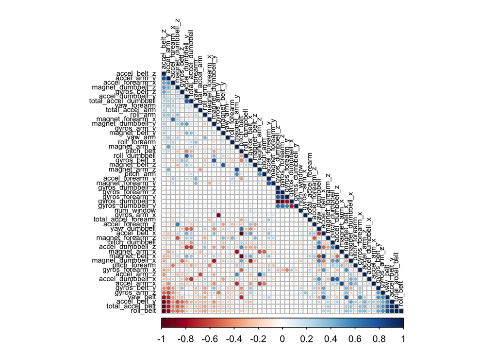

```r
corr_matrix <- cor(train_set[ , -54])
corrplot(corr_matrix, order = "FPC", method = "circle", type = "lower",
         tl.cex = 0.6, tl.col = rgb(0, 0, 0))
```

# Choose an appropriate Model

We perform our modelling using 3 models 1. Decision Tree Model 2. Generalized Boosted Model 3. Random Forests

### 1. Decision Tree Model

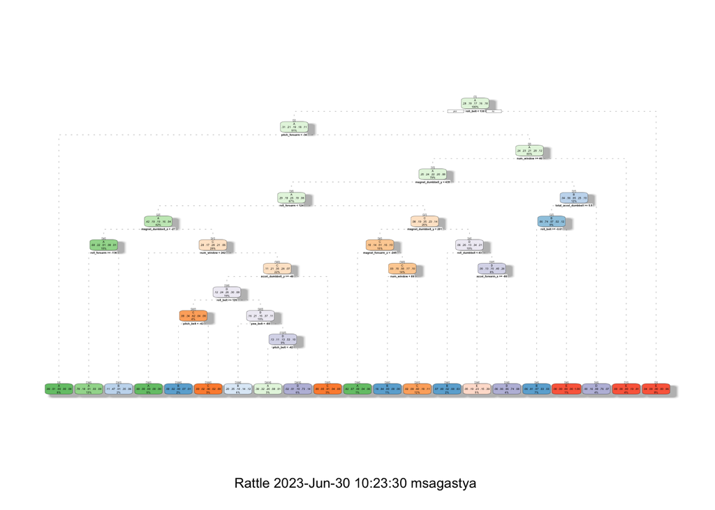

```r
set.seed(1967)
fit_DT <- rpart(classe ~ ., data = train_set, method="class")
fancyRpartPlot(fit_DT)
```

```r
predict_DT <- predict(fit_DT, newdata = test_set, type="class")
conf_matrix_DT <- confusionMatrix(table(predict_DT, test_set$classe))
conf_matrix_DT
```

```
## Confusion Matrix and Statistics
##
##
## predict_DT    A    B    C    D    E
##          A 1460  177   29   37   13
##          B  124  775   96  156   81
##          C   19   69  800  130   87
##          D   28   49   47  536   83
##          E   43   69   54  105  818
##
## Overall Statistics
##
##                Accuracy : 0.7458
##                  95% CI : (0.7345, 0.7569)
##     No Information Rate : 0.2845
##     P-Value [Acc > NIR] : < 2.2e-16
##
##                   Kappa : 0.6779
##
##  Mcnemar's Test P-Value : < 2.2e-16
##
## Statistics by Class:
##
##                      Class: A Class: B Class: C Class: D Class: E
## Sensitivity            0.8722   0.6804   0.7797  0.55602   0.7560
## Specificity            0.9392   0.9037   0.9372  0.95794   0.9436
## Pos Pred Value         0.8508   0.6291   0.7240  0.72140   0.7511
## Neg Pred Value         0.9487   0.9218   0.9527  0.91676   0.9450
## Prevalence             0.2845   0.1935   0.1743  0.16381   0.1839
## Detection Rate         0.2481   0.1317   0.1359  0.09108   0.1390
## Detection Prevalence   0.2916   0.2093   0.1878  0.12625   0.1850
## Balanced Accuracy      0.9057   0.7921   0.8585  0.75698   0.8498
```

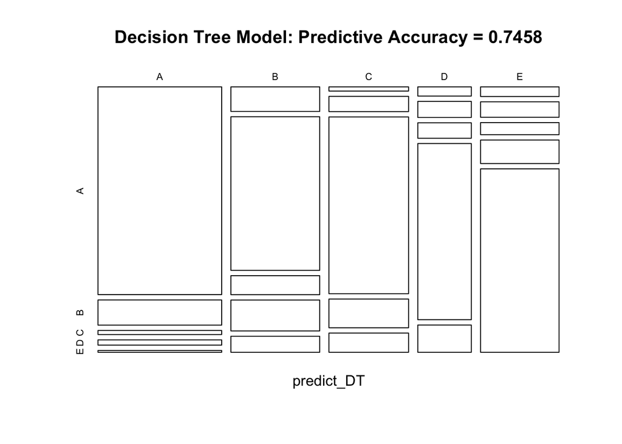

```r
plot(conf_matrix_DT$table, col = conf_matrix_DT$byClass,
     main = paste("Decision Tree Model: Predictive Accuracy =",
                  round(conf_matrix_DT$overall['Accuracy'], 4)))
```

### 2. Generalized Boosted Model(GBM)

```r
set.seed(1967)
ctrl_GBM <- trainControl(method = "repeatedcv", number = 5, repeats = 2)
fit_GBM  <- train(classe ~ ., data = train_set, method = "gbm",
                  trControl = ctrl_GBM, verbose = FALSE)
fit_GBM$finalModel
```

```
## A gradient boosted model with multinomial loss function.
## 150 iterations were performed.
## There were 53 predictors of which 53 had non-zero influence.
```

```r
predict_GBM <- predict(fit_GBM, newdata = test_set)
conf_matrix_GBM <- confusionMatrix(table(predict_GBM, test_set$classe))
conf_matrix_GBM
```

```
## Confusion Matrix and Statistics
##
##
## predict_GBM    A    B    C    D    E
##           A 1665   14    0    1    1
##           B    8 1118    9    2    4
##           C    0    7 1015    8    3
##           D    1    0    2  953    9
##           E    0    0    0    0 1065
##
## Overall Statistics
##
##                Accuracy : 0.9883
##                  95% CI : (0.9852, 0.9909)
##     No Information Rate : 0.2845
##     P-Value [Acc > NIR] : < 2.2e-16
##
##                   Kappa : 0.9852
##
##  Mcnemar's Test P-Value : NA
##
## Statistics by Class:
##
##                      Class: A Class: B Class: C Class: D Class: E
## Sensitivity            0.9946   0.9816   0.9893   0.9886   0.9843
## Specificity            0.9962   0.9952   0.9963   0.9976   1.0000
## Pos Pred Value         0.9905   0.9798   0.9826   0.9876   1.0000
## Neg Pred Value         0.9979   0.9956   0.9977   0.9978   0.9965
## Prevalence             0.2845   0.1935   0.1743   0.1638   0.1839
## Detection Rate         0.2829   0.1900   0.1725   0.1619   0.1810
## Detection Prevalence   0.2856   0.1939   0.1755   0.1640   0.1810
## Balanced Accuracy      0.9954   0.9884   0.9928   0.9931   0.9921
```

### 3. Random Forest

```r
set.seed(1967)
ctrl_RF <- trainControl(method = "repeatedcv", number = 5, repeats = 2)
fit_RF  <- train(classe ~ ., data = train_set, method = "rf",
                 trControl = ctrl_RF, verbose = FALSE)
fit_RF$finalModel
```

```
##
## Call:
##  randomForest(x = x, y = y, mtry = param$mtry, verbose = FALSE)
##                Type of random forest: classification
##                      Number of trees: 500
## No. of variables tried at each split: 27
##
##         OOB estimate of  error rate: 0.2%
## Confusion matrix:
##      A    B    C    D    E  class.error
## A 3905    0    0    0    1 0.0002560164
## B    7 2648    3    0    0 0.0037622272
## C    0    4 2391    1    0 0.0020868114
## D    0    0    4 2246    2 0.0026642984
## E    0    0    0    6 2519 0.0023762376
```

```r
predict_RF <- predict(fit_RF, newdata = test_set)
conf_matrix_RF <- confusionMatrix(table(predict_RF, test_set$classe))
conf_matrix_RF
```

```
## Confusion Matrix and Statistics
##
##
## predict_RF    A    B    C    D    E
##          A 1674    1    0    0    0
##          B    0 1137    1    0    0
##          C    0    1 1025    3    0
##          D    0    0    0  961    2
##          E    0    0    0    0 1080
##
## Overall Statistics
##
##                Accuracy : 0.9986
##                  95% CI : (0.9973, 0.9994)
##     No Information Rate : 0.2845
##     P-Value [Acc > NIR] : < 2.2e-16
##
##                   Kappa : 0.9983
##
##  Mcnemar's Test P-Value : NA
##
## Statistics by Class:
##
##                      Class: A Class: B Class: C Class: D Class: E
## Sensitivity            1.0000   0.9982   0.9990   0.9969   0.9982
## Specificity            0.9998   0.9998   0.9992   0.9996   1.0000
## Pos Pred Value         0.9994   0.9991   0.9961   0.9979   1.0000
## Neg Pred Value         1.0000   0.9996   0.9998   0.9994   0.9996
## Prevalence             0.2845   0.1935   0.1743   0.1638   0.1839
## Detection Rate         0.2845   0.1932   0.1742   0.1633   0.1835
## Detection Prevalence   0.2846   0.1934   0.1749   0.1636   0.1835
## Balanced Accuracy      0.9999   0.9990   0.9991   0.9982   0.9991
```

# Evaluate the Model (Fitting models)

## Summary

Accuracy: * Decision Tree Model : 74.58%% * Generalized Boosted Model : 98.83% * Random Forest : 99.86%

The kappa statistic The kappa statistic (labeled Kappa in the previous output) adjusts accuracy by accounting for the possibility of a correct prediction by chance alone. Kappa values range to a maximum value of 1, which indicates perfect agreement between the model’s predictions and the true values—a rare occurrence. Values less than one indicate imperfect agreement.

Depending on how your model is to be used, the interpretation of the kappa statistic might vary. One common interpretation is shown as follows: • Poor agreement = Less than 0.20 • Fair agreement = 0.20 to 0.40 • Moderate agreement = 0.40 to 0.60 • Good agreement = 0.60 to 0.80 • Very good agreement = 0.80 to 1.00

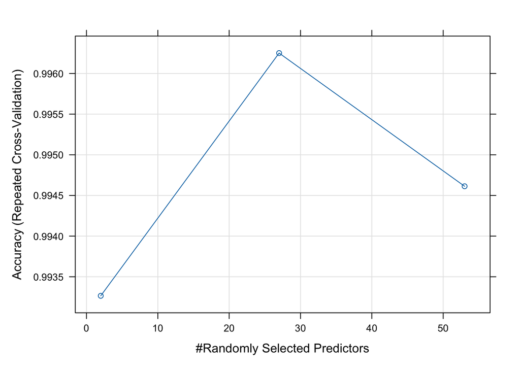

```r
plot(fit_RF)
```

```r
print(fit_RF$bestTune)
```

```
##   mtry
## 2   27
```

# Make Predictions Deciding to predict with this model.

The Random Forest model is selected and applied to make predictions on the 20 data points from the original testing dataset (testing_data).

```r
cat("Predictions: ", paste(predict(fit_RF, testing_data)))
```

```
## Predictions:  B A B A A E D B A A B C B A E E A B B B
```